# 2019 Baywheels or Ford GoBike Data Exploration and Visualization

## Preliminary Wrangling

> Baywheels (previously known as Ford GoBike) is a regional bike sharing system in greater San Francisco Bay Area. It is the first regional and large-scale bicycle sharing system deployed in California and on the West Coast of the United States. It was established as Bay Area Bike Share in August 2013. As of January 2018, the Bay Wheels system had over 2,600 bicycles in 262 stations across San Francisco, East Bay and San Jose. The dataset conatains the historical monthly trip data starting from 2017 to 2020. I have selected the data for the year of 2019 for my analysis.

```python
# import all packages and set plots to be embedded inline
%matplotlib inline

import numpy as np
import pandas as pd
import matplotlib.pyplot as plt
import seaborn as sb
import os
import glob
from datetime import datetime as dt
```

```python
# Reading in all the csv files and storing in df dataframe, also writing to 1 master csv file
path ='./GoBikeData/'
files = glob.glob(os.path.join(path, "*.csv"))
df = pd.concat((pd.read_csv(f) for f in files), ignore_index = True)
```

```python
df.info()
```

```
<class 'pandas.core.frame.DataFrame'>
RangeIndex: 2506983 entries, 0 to 2506982
Data columns (total 15 columns):
 #   Column                   Dtype
---  ------                   -----
 0   duration_sec             int64
 1   start_time               object
 2   end_time                 object
 3   start_station_id         float64
 4   start_station_name       object
 5   start_station_latitude   float64
 6   start_station_longitude  float64
 7   end_station_id           float64
 8   end_station_name         object
 9   end_station_latitude     float64
 10  end_station_longitude    float64
 11  bike_id                  int64
 12  user_type                object
 13  bike_share_for_all_trip  object
 14  rental_access_method     object
dtypes: float64(6), int64(2), object(7)
memory usage: 286.9+ MB
```

```python
df.head()
```

|  | duration_sec | start_time | end_time | start_station_id | start_station_name | start_station_latitude | start_station_longitude | end_station_id | end_station_name | end_station_latitude | end_station_longitude | bike_id | user_type | bike_share_for_all_trip | rental_access_method |
| --- | --- | --- | --- | --- | --- | --- | --- | --- | --- | --- | --- | --- | --- | --- | --- |
| 0 | 80825 | 2019-01-31 17:57:44.6130 | 2019-02-01 16:24:49.8640 | 229.0 | Foothill Blvd at 42nd Ave | 37.775745 | -122.213037 | 196.0 | Grand Ave at Perkins St | 37.808894 | -122.256460 | 4861 | Subscriber | No | NaN |
| 1 | 65900 | 2019-01-31 20:58:33.8860 | 2019-02-01 15:16:54.1730 | 4.0 | Cyril Magnin St at Ellis St | 37.785881 | -122.408915 | 134.0 | Valencia St at 24th St | 37.752428 | -122.420628 | 5506 | Subscriber | No | NaN |
| 2 | 62633 | 2019-01-31 18:06:52.9240 | 2019-02-01 11:30:46.5300 | 245.0 | Downtown Berkeley BART | 37.870139 | -122.268422 | 157.0 | 65th St at Hollis St | 37.846784 | -122.291376 | 2717 | Customer | No | NaN |
| 3 | 44680 | 2019-01-31 19:46:09.7190 | 2019-02-01 08:10:50.3180 | 85.0 | Church St at Duboce Ave | 37.770083 | -122.429156 | 53.0 | Grove St at Divisadero | 37.775946 | -122.437777 | 4557 | Customer | No | NaN |
| 4 | 60709 | 2019-01-31 14:19:01.5410 | 2019-02-01 07:10:51.0650 | 16.0 | Steuart St at Market St | 37.794130 | -122.394430 | 28.0 | The Embarcadero at Bryant St | 37.787168 | -122.388098 | 2100 | Customer | No | NaN |

```python
df.describe()
```

|  | duration_sec | start_station_id | start_station_latitude | start_station_longitude | end_station_id | end_station_latitude | end_station_longitude | bike_id |
| --- | --- | --- | --- | --- | --- | --- | --- | --- |
| count | 2.506983e+06 | 2.426249e+06 | 2.506983e+06 | 2.506983e+06 | 2.424081e+06 | 2.506983e+06 | 2.506983e+06 | 2.506983e+06 |
| mean | 8.076483e+02 | 1.465047e+02 | 3.776506e+01 | -1.223499e+02 | 1.427044e+02 | 3.776422e+01 | -1.223459e+02 | 2.789833e+04 |
| std | 1.974714e+03 | 1.223171e+02 | 1.363698e-01 | 3.089648e-01 | 1.214296e+02 | 2.392885e-01 | 7.080417e-01 | 1.146067e+05 |
| min | 6.000000e+01 | 3.000000e+00 | 0.000000e+00 | -1.225143e+02 | 3.000000e+00 | 0.000000e+00 | -1.225143e+02 | 4.000000e+00 |
| 25% | 3.590000e+02 | 4.700000e+01 | 3.776931e+01 | -1.224130e+02 | 4.300000e+01 | 3.777003e+01 | -1.224117e+02 | 1.952000e+03 |
| 50% | 5.710000e+02 | 1.050000e+02 | 3.778053e+01 | -1.223983e+02 | 1.010000e+02 | 3.778076e+01 | -1.223981e+02 | 4.420000e+03 |
| 75% | 8.870000e+02 | 2.430000e+02 | 3.779539e+01 | -1.222914e+02 | 2.390000e+02 | 3.779587e+01 | -1.222934e+02 | 9.682000e+03 |
| max | 9.121100e+05 | 4.980000e+02 | 4.551000e+01 | 0.000000e+00 | 4.980000e+02 | 4.551000e+01 | 0.000000e+00 | 9.999410e+05 |

### What is the structure of your dataset?

> The dataset has 2506983 rows and 15 columns which can be logically grouped as follows:
> - `Trip information:` duration_sec, start_time, end_time
> - `Start station info.:` start_station_id, start_station_name, start_station_latitude, start_station_longitude
> - `End station info:` end_station_id, end_station_name, end_station_latitude, end_station_longitude
> - `Other info.:` bike_id, user_type, bike_share_for_all_trip, rental_access_method

### What is/are the main feature(s) of interest in your dataset?

> I am interested in seeing how the trip duration varies, which type of users have more trips, which stations are more frequently used, the rental access methods and the bike share for all information for the trips. I would also like to investigate when is there a peak in the number of trips - what time of the day, which day of the week, which month of the year etc. In order to accomplish this, the start time needs to be converted from a string type to a datetime object. Also, having the trip duration in minutes might be more precise and easier to understand.

### What features in the dataset do you think will help support your investigation into your feature(s) of interest?

> The parameters duration_sec (will add a column for duration in minutes),start_time,start_station_id,end_station_id,bike_id,user_type,bike_share_for_all_trip,rental_access_method are useful for my analysis. Also, once the start_time is transformed into a datetime object, that would add additional columns which are useful in the analysis.

## Cleaning

```python
# Making a copy of the dataframe for cleaning
df_clean = df.copy()
df_clean['duration_minutes'] = df_clean['duration_sec']/60
df_clean.head()
```

|  | duration_sec | start_time | end_time | start_station_id | start_station_name | start_station_latitude | start_station_longitude | end_station_id | end_station_name | end_station_latitude | end_station_longitude | bike_id | user_type | bike_share_for_all_trip | rental_access_method | duration_minutes |
| --- | --- | --- | --- | --- | --- | --- | --- | --- | --- | --- | --- | --- | --- | --- | --- | --- |
| 0 | 80825 | 2019-01-31 17:57:44.6130 | 2019-02-01 16:24:49.8640 | 229.0 | Foothill Blvd at 42nd Ave | 37.775745 | -122.213037 | 196.0 | Grand Ave at Perkins St | 37.808894 | -122.256460 | 4861 | Subscriber | No | NaN | 1347.083333 |
| 1 | 65900 | 2019-01-31 20:58:33.8860 | 2019-02-01 15:16:54.1730 | 4.0 | Cyril Magnin St at Ellis St | 37.785881 | -122.408915 | 134.0 | Valencia St at 24th St | 37.752428 | -122.420628 | 5506 | Subscriber | No | NaN | 1098.333333 |
| 2 | 62633 | 2019-01-31 18:06:52.9240 | 2019-02-01 11:30:46.5300 | 245.0 | Downtown Berkeley BART | 37.870139 | -122.268422 | 157.0 | 65th St at Hollis St | 37.846784 | -122.291376 | 2717 | Customer | No | NaN | 1043.883333 |
| 3 | 44680 | 2019-01-31 19:46:09.7190 | 2019-02-01 08:10:50.3180 | 85.0 | Church St at Duboce Ave | 37.770083 | -122.429156 | 53.0 | Grove St at Divisadero | 37.775946 | -122.437777 | 4557 | Customer | No | NaN | 744.666667 |
| 4 | 60709 | 2019-01-31 14:19:01.5410 | 2019-02-01 07:10:51.0650 | 16.0 | Steuart St at Market St | 37.794130 | -122.394430 | 28.0 | The Embarcadero at Bryant St | 37.787168 | -122.388098 | 2100 | Customer | No | NaN | 1011.816667 |

```python
df_clean['start_time']= pd.to_datetime(df_clean['start_time'])
df_clean.head()
```

|  | duration_sec | start_time | end_time | start_station_id | start_station_name | start_station_latitude | start_station_longitude | end_station_id | end_station_name | end_station_latitude | end_station_longitude | bike_id | user_type | bike_share_for_all_trip | rental_access_method | duration_minutes |
| --- | --- | --- | --- | --- | --- | --- | --- | --- | --- | --- | --- | --- | --- | --- | --- | --- |
| 0 | 80825 | 2019-01-31 17:57:44.613 | 2019-02-01 16:24:49.8640 | 229.0 | Foothill Blvd at 42nd Ave | 37.775745 | -122.213037 | 196.0 | Grand Ave at Perkins St | 37.808894 | -122.256460 | 4861 | Subscriber | No | NaN | 1347.083333 |
| 1 | 65900 | 2019-01-31 20:58:33.886 | 2019-02-01 15:16:54.1730 | 4.0 | Cyril Magnin St at Ellis St | 37.785881 | -122.408915 | 134.0 | Valencia St at 24th St | 37.752428 | -122.420628 | 5506 | Subscriber | No | NaN | 1098.333333 |
| 2 | 62633 | 2019-01-31 18:06:52.924 | 2019-02-01 11:30:46.5300 | 245.0 | Downtown Berkeley BART | 37.870139 | -122.268422 | 157.0 | 65th St at Hollis St | 37.846784 | -122.291376 | 2717 | Customer | No | NaN | 1043.883333 |
| 3 | 44680 | 2019-01-31 19:46:09.719 | 2019-02-01 08:10:50.3180 | 85.0 | Church St at Duboce Ave | 37.770083 | -122.429156 | 53.0 | Grove St at Divisadero | 37.775946 | -122.437777 | 4557 | Customer | No | NaN | 744.666667 |
| 4 | 60709 | 2019-01-31 14:19:01.541 | 2019-02-01 07:10:51.0650 | 16.0 | Steuart St at Market St | 37.794130 | -122.394430 | 28.0 | The Embarcadero at Bryant St | 37.787168 | -122.388098 | 2100 | Customer | No | NaN | 1011.816667 |

```python
# Adding additional columns for just the month&date and hour so we can understand the peak times of the trips
df_clean['trip_date'] = df_clean.start_time.dt.strftime('%m-%d')
df_clean['trip_time'] = df_clean.start_time.dt.strftime('%H')
df_clean['trip_day'] = df_clean.start_time.dt.strftime('%A')
df_clean['trip_month'] = df_clean.start_time.dt.strftime('%B')
df_clean.head()
```

|  | duration_sec | start_time | end_time | start_station_id | start_station_name | start_station_latitude | start_station_longitude | end_station_id | end_station_name | end_station_latitude | end_station_longitude | bike_id | user_type | bike_share_for_all_trip | rental_access_method | duration_minutes | trip_date | trip_time | trip_day | trip_month |
| --- | --- | --- | --- | --- | --- | --- | --- | --- | --- | --- | --- | --- | --- | --- | --- | --- | --- | --- | --- | --- |
| 0 | 80825 | 2019-01-31 17:57:44.613 | 2019-02-01 16:24:49.8640 | 229.0 | Foothill Blvd at 42nd Ave | 37.775745 | -122.213037 | 196.0 | Grand Ave at Perkins St | 37.808894 | -122.256460 | 4861 | Subscriber | No | NaN | 1347.083333 | 01-31 | 17 | Thursday | January |
| 1 | 65900 | 2019-01-31 20:58:33.886 | 2019-02-01 15:16:54.1730 | 4.0 | Cyril Magnin St at Ellis St | 37.785881 | -122.408915 | 134.0 | Valencia St at 24th St | 37.752428 | -122.420628 | 5506 | Subscriber | No | NaN | 1098.333333 | 01-31 | 20 | Thursday | January |
| 2 | 62633 | 2019-01-31 18:06:52.924 | 2019-02-01 11:30:46.5300 | 245.0 | Downtown Berkeley BART | 37.870139 | -122.268422 | 157.0 | 65th St at Hollis St | 37.846784 | -122.291376 | 2717 | Customer | No | NaN | 1043.883333 | 01-31 | 18 | Thursday | January |
| 3 | 44680 | 2019-01-31 19:46:09.719 | 2019-02-01 08:10:50.3180 | 85.0 | Church St at Duboce Ave | 37.770083 | -122.429156 | 53.0 | Grove St at Divisadero | 37.775946 | -122.437777 | 4557 | Customer | No | NaN | 744.666667 | 01-31 | 19 | Thursday | January |
| 4 | 60709 | 2019-01-31 14:19:01.541 | 2019-02-01 07:10:51.0650 | 16.0 | Steuart St at Market St | 37.794130 | -122.394430 | 28.0 | The Embarcadero at Bryant St | 37.787168 | -122.388098 | 2100 | Customer | No | NaN | 1011.816667 | 01-31 | 14 | Thursday | January |

```python
#Checking to see if there are any duplicate rows
df_clean[df_clean.duplicated()].shape
```

```
(0, 20)
```

## Univariate Exploration

```python
hour_labels = df_clean['trip_time'].unique().tolist()
hour_labels.sort()
hour_labels
```

```
['00',
 '01',
 '02',
 '03',
 '04',
 '05',
 '06',
 '07',
 '08',
 '09',
 '10',
 '11',
 '12',
 '13',
 '14',
 '15',
 '16',
 '17',
 '18',
 '19',
 '20',
 '21',
 '22',
 '23']
```

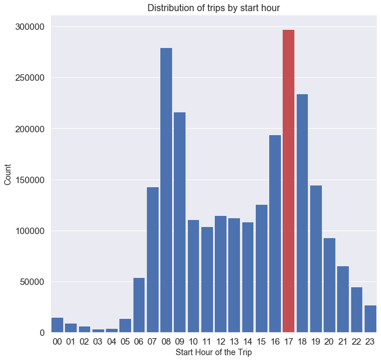

```python
# Distribution of the trips by hour in 2019
base_color = sb.color_palette()[0]
sb.set_style("darkgrid")
plt.figure(figsize=[10,10])
ax=sb.countplot(data = df_clean,x = df_clean['trip_time'],color = base_color,order=hour_labels)
plt.xlabel('Start Hour of the Trip',fontsize=14);
plt.ylabel('Count',fontsize=14);
plt.title('Distribution of trips by start hour',fontsize=16);

heights=[]
for bar in ax.patches:
    heights.append(bar.get_height())

for bar in ax.patches:
    if bar.get_height() == max(heights):
        bar.set_color('r')
    else:
        bar.set_color(base_color)
```

> **It looks like the highest number of trips start at 17 i.e. 5PM followed by 8AM. This makes sense because these are typically the start and end hours for work schedule and peak traffic is expected.**

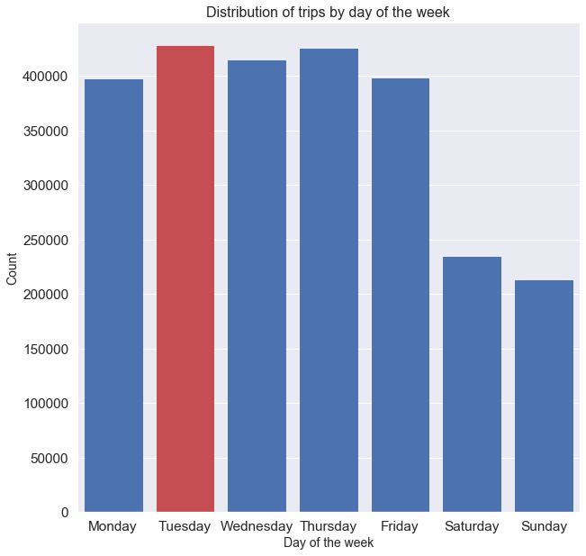

```python
# Distribution of the trips by day of the week in 2019
base_color = sb.color_palette()[0]
sb.set_style("darkgrid")
plt.figure(figsize=[10,10])
ax = sb.countplot(data = df_clean, x = df_clean['trip_day'], color = base_color,order=['Monday','Tuesday','Wednesday','Thursday','Friday','Saturday','Sunday'])
plt.xlabel('Day of the week',fontsize=14);
plt.ylabel('Count',fontsize=14);
plt.title('Distribution of trips by day of the week',fontsize=16);

heights=[]
for bar in ax.patches:
    heights.append(bar.get_height())

for bar in ax.patches:
    if bar.get_height() == max(heights):
        bar.set_color('r')
    else:
        bar.set_color(base_color)
```

> **From the above graph, it looks like Tuesdays have the highest number of trips in 2019. The number of trips is low, over the weekends.**

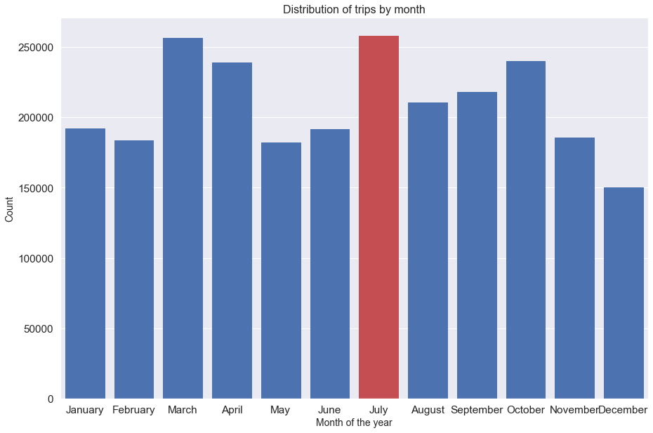

```python
# Distribution of trips by month in 2019
base_color = sb.color_palette()[0]
sb.set_style("darkgrid")
plt.figure(figsize=[15,10])
ax = sb.countplot(data = df_clean, x = df_clean['trip_month'], color = base_color,order=['January','February','March','April','May','June','July','August','September','October','November','December'])
plt.xlabel('Month of the year',fontsize=14);
plt.ylabel('Count',fontsize=14);
plt.title('Distribution of trips by month',fontsize=16);

heights=[]
for bar in ax.patches:
    heights.append(bar.get_height())

for bar in ax.patches:
    if bar.get_height() == max(heights):
        bar.set_color('r')
    else:
        bar.set_color(base_color)
```

> **July had the highest number of trips while December had the least number of trips in 2019.**

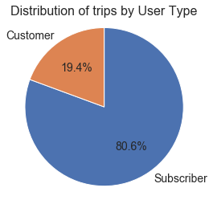

```python
# Distribution of trips by User Type
sorted_counts = df_clean['user_type'].value_counts();
plt.pie(sorted_counts, labels = sorted_counts.index, startangle = 90,counterclock = False,autopct='%1.1f%%',textprops={'fontsize': 14});
plt.axis('square');
plt.title('Distribution of trips by User Type',fontsize=16);
```

> **Of all the trips in 2019, 80.6% users were Subscribers which means they were members. The remaining 19.4% were Customers i.e. casual users.**

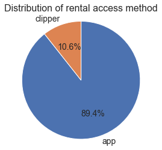

```python
# Distribution of rental access methods
sorted_counts = df_clean['rental_access_method'].value_counts();
plt.pie(sorted_counts, labels = sorted_counts.index,startangle = 90,counterclock = False,autopct='%1.1f%%',textprops={'fontsize': 14});
plt.axis('square');
plt.title('Distribution of rental access method',fontsize=16);
```

> **Of all the trips in 2019, 89.4% users used the app for access while the remaining 10.6% users used Clipper card for access (more info. here - https://www.lyft.com/bikes/bay-wheels/clipper-card).**

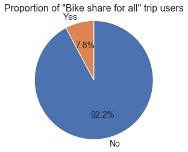

```python
# Proportion of "Bike share for all" trip users
sorted_counts = df_clean['bike_share_for_all_trip'].value_counts();
plt.pie(sorted_counts, labels = sorted_counts.index, startangle = 90,counterclock = False,autopct='%1.1f%%',textprops={'fontsize': 14});
plt.axis('square');
plt.title('Proportion of "Bike share for all" trip users',fontsize=16);
```

> **Of all the trips in 2019, 7.8% users used the "Bike share for all" affordable option while the remaining 92.2% were were regular users (more info. here - https://www.lyft.com/bikes/bay-wheels/bike-share-for-all).**

```python
df_clean.duration_minutes.describe()
```

```
count    2.506983e+06
mean     1.346081e+01
std      3.291190e+01
min      1.000000e+00
25%      5.983333e+00
50%      9.516667e+00
75%      1.478333e+01
max      1.520183e+04
Name: duration_minutes, dtype: float64
```

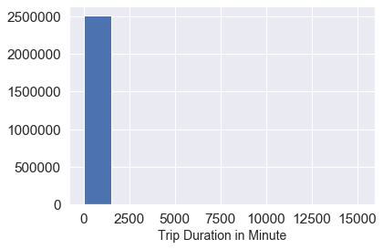

```python
# Variation of the Trip Duration in minutes
plt.hist(data=df_clean, x='duration_minutes');
plt.xlabel('Trip Duration in Minute',fontsize=14);
```

> **Although the maximum trip duration seems to be 15200 minutes (which is odd) from the describe() output, it looks like the trip duration is typically between 0 and 2000 minutes. It is possible that the really high values are outliers.**

```python
df_clean['duration_minutes'].describe(percentiles=[.99])
```

```
count    2.506983e+06
mean     1.346081e+01
std      3.291190e+01
min      1.000000e+00
50%      9.516667e+00
99%      6.876667e+01
max      1.520183e+04
Name: duration_minutes, dtype: float64
```

> **Therefore, it looks like 99% trips are ~68 minutes approximately.**

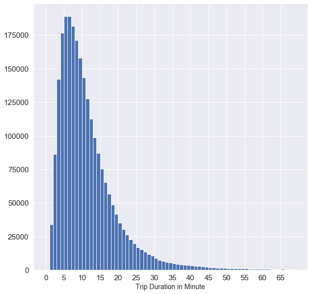

```python
bins = np.arange(0, 70, 1)
ticks = np.arange(0, 70, 5)
plt.figure(figsize=[10,10]);
plt.hist(data=df_clean, x='duration_minutes', bins=bins);
plt.xticks(ticks, ticks);
plt.xlabel('Trip Duration in Minute',fontsize=14);
```

```python
# Removing the outliers in the trip duration
df_clean[df_clean.duration_minutes>70].shape
```

```
(24415, 20)
```

> **There are about 24,415 rows (total rows=2506983, so only about 0.97% of data) which have values greater than 70 minutes. Therefore, dropping these rows.**

```python
rows_to_drop = df_clean[df_clean.duration_minutes>70].index
df_clean.drop(rows_to_drop,inplace=True)
df_clean.info()
```

```
<class 'pandas.core.frame.DataFrame'>
Int64Index: 2482568 entries, 6 to 2506982
Data columns (total 20 columns):
 #   Column                   Dtype
---  ------                   -----
 0   duration_sec             int64
 1   start_time               datetime64[ns]
 2   end_time                 object
 3   start_station_id         float64
 4   start_station_name       object
 5   start_station_latitude   float64
 6   start_station_longitude  float64
 7   end_station_id           float64
 8   end_station_name         object
 9   end_station_latitude     float64
 10  end_station_longitude    float64
 11  bike_id                  int64
 12  user_type                object
 13  bike_share_for_all_trip  object
 14  rental_access_method     object
 15  duration_minutes         float64
 16  trip_date                object
 17  trip_time                object
 18  trip_day                 object
 19  trip_month               object
dtypes: datetime64[ns](1), float64(7), int64(2), object(10)
memory usage: 397.8+ MB
```

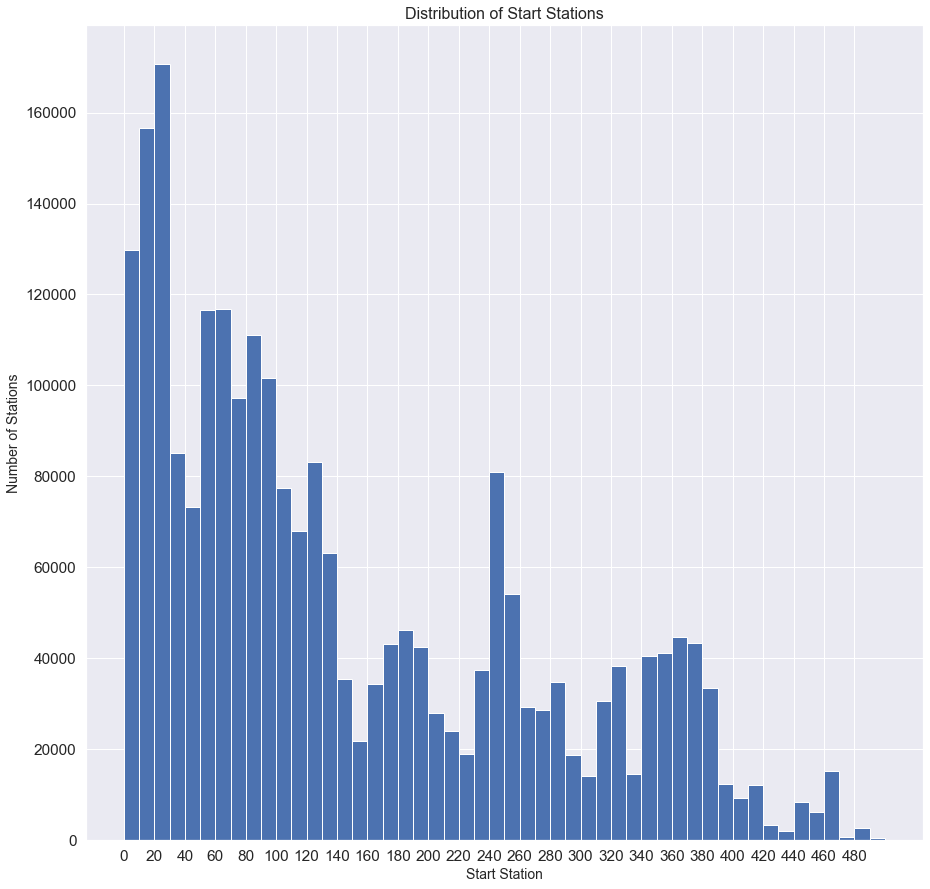

```python
# The start station IDs distribution across trips
binsize = 10
bins = np.arange(0, df_clean['start_station_id'].max()+binsize, binsize)
plt.figure(figsize=[15, 15])
plt.xticks(range(0,500, 20)) #plotting from 0 to 500 since the max value for start station ID seems to be 498 from the df_clean.describe() output above
plt.hist(data = df_clean, x = 'start_station_id', bins = bins)
plt.title('Distribution of Start Stations',fontsize=16)
plt.xlabel('Start Station',fontsize=14)
plt.ylabel('Number of Stations',fontsize=14)
plt.show()
```

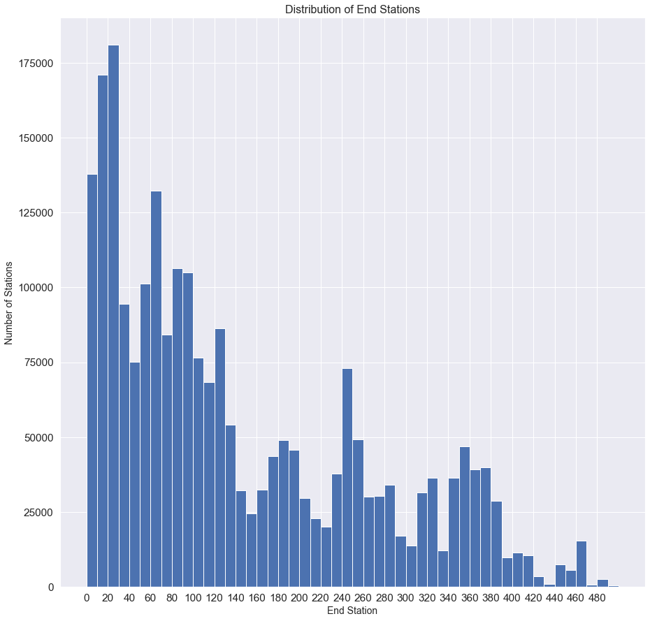

```python
# The end station IDs distribution across trips
binsize = 10
bins = np.arange(0, df_clean['end_station_id'].max()+binsize, binsize)
plt.figure(figsize=[15, 15])
plt.xticks(range(0,500, 20)) #plotting from 0 to 500 since the max value for end station ID seems to be 498 from the df_clean.describe() output above
plt.hist(data = df_clean, x = 'end_station_id', bins = bins)
plt.title('Distribution of End Stations',fontsize=16)
plt.xlabel('End Station',fontsize=14)
plt.ylabel('Number of Stations',fontsize=14)
plt.show()
```

> **The 2 histograms above look quite similar which implies that the same stations are most frequently used as both the start and end stations for the trips.**

```python
# Storing this cleaned data into a CSV file
df_clean.to_csv('master_file.csv', index=False)
```

### Discuss the distribution(s) of your variable(s) of interest. Were there any unusual points? Did you need to perform any transformations?

> I am interested in seeing how the trip duration varies, which type of users have more trips etc. I would also like to investigate when is there a peak in the number of trips - which time of the day, which day of the week etc. In order to accomplish this, the start time needs to be converted from a string type to a datetime object. Therefore, I have added 4 new columns - 'trip_date','trip_time','trip_day' and 'trip_month' and filled these with information from the start_time column. Also, having the trip duration in minutes might be more precise and easier to understand. Therefore, I have added a new column 'duration_minutes'.  
> 1.It looks like the highest number of trips start at 17 i.e. 5PM followed by 8AM. This makes sense because this is typically the work schedule and peak traffic is expected.  
> 2.From the above graph, it looks like Tuesdays have the highest number of trips in 2019. The number of trips is low, over the weekends.  
> 3.July had the highest number of trips while December had the least number of trips in 2019.  
> 4.Of all the trips in 2019, 80.6% users were Subscribers which means they were members. The remaining 19.4% were Customers i.e. casual users.  
> 5.It seems 89.4% users used the app for access while the remaining 10.6% users used Clipper card for access (more info. here - https://www.lyft.com/bikes/bay-wheels/clipper-card).  
> 6.7.8% users used the "Bike share for all" affordable option while the remaining 92.2% were were regular users (more info. here - https://www.lyft.com/bikes/bay-wheels/bike-share-for-all).  
> 7.The 2 histograms showing the distribution of the starting and end station IDs look quite similar which implies that the same stations are most frequently used as both the start and end stations for the trips.

### Of the features you investigated, were there any unusual distributions? Did you perform any operations on the data to tidy, adjust, or change the form of the data? If so, why did you do this?

> The maximum trip duration seemed to be 15200 minutes (which is odd) from the describe() output. It looks like the trip duration is typically between 0 and 2000 minutes and it is possible that the really high values are outliers. Therefore, it looks like 99% trips are ~68 minutes approximately.There are about 24,415 rows (total rows=2506983, so only about 0.97% of data) which have values greater than 70 minutes. Therefore, I have dropped these rows.

## Bivariate Exploration

```python
df_clean.head(1)
```

|  | duration_sec | start_time | end_time | start_station_id | start_station_name | start_station_latitude | start_station_longitude | end_station_id | end_station_name | end_station_latitude | end_station_longitude | bike_id | user_type | bike_share_for_all_trip | rental_access_method | duration_minutes | trip_date | trip_time | trip_day | trip_month |
| --- | --- | --- | --- | --- | --- | --- | --- | --- | --- | --- | --- | --- | --- | --- | --- | --- | --- | --- | --- | --- |
| 6 | 1188 | 2019-01-31 23:54:38.901 | 2019-02-01 00:14:27.9000 | 34.0 | Father Alfred E Boeddeker Park | 37.783988 | -122.412408 | 146.0 | 30th St at San Jose Ave | 37.742314 | -122.42318 | 5114 | Subscriber | No | NaN | 19.8 | 01-31 | 23 | Thursday | January |

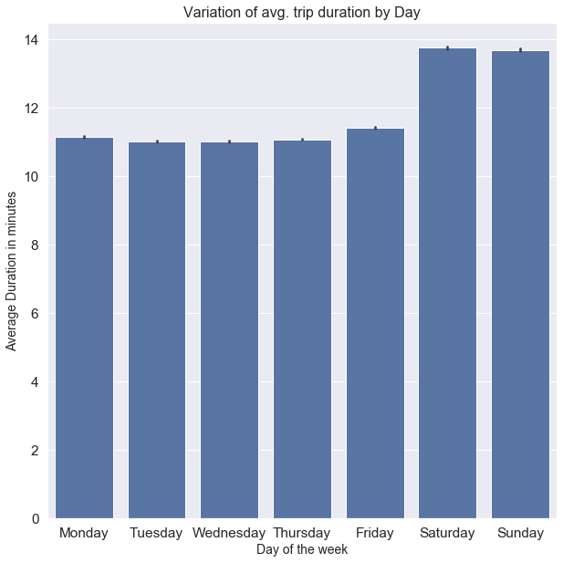

```python
# How does trip duration vary by the day of the week?
plt.figure(figsize=[10,10])
sb.barplot(x='trip_day',y='duration_minutes',data=df_clean,color = base_color,order=['Monday','Tuesday','Wednesday','Thursday','Friday','Saturday','Sunday']);
plt.xlabel('Day of the week',fontsize=14);
plt.ylabel('Average Duration in minutes',fontsize=14);
plt.title('Variation of avg. trip duration by Day',fontsize=16);
```

> **The trip duration on weekends seem to be higher as compared to weekdays (could be because people are using the bikes for sightseeing etc. on weekends).**

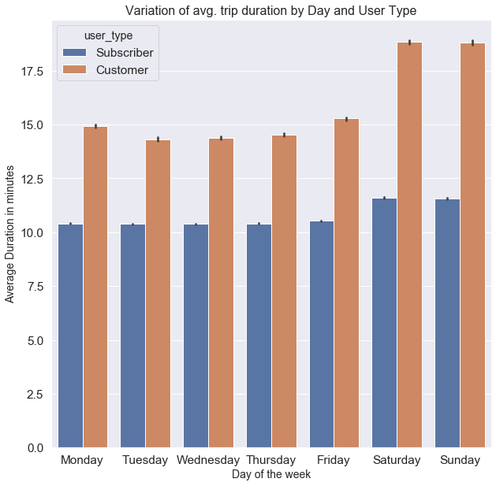

```python
# Let's see if the above trend changes by user type
plt.figure(figsize=[10,10])
sb.barplot(x='trip_day',y='duration_minutes',hue='user_type',data=df_clean,order=['Monday','Tuesday','Wednesday','Thursday','Friday','Saturday','Sunday']);
plt.xlabel('Day of the week',fontsize=14);
plt.ylabel('Average Duration in minutes',fontsize=14);
plt.title('Variation of avg. trip duration by Day and User Type',fontsize=16);
```

> **So our suspicion about that the bikes could've been used for sightseeing etc. on weekends. seems to be true. The average trip duration seems to be constant for subscribers who could be using these for routine tasks. However, the customers could be using them on weekends for sight-seeing or for leisure because there is a significant increase in trip duration over the weekends for "Customers".**

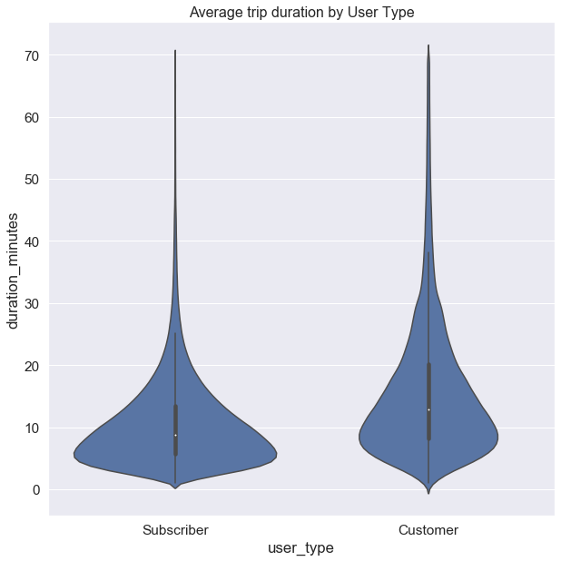

```python
# Average trip duration by User Type
base_color = sb.color_palette()[0];
plt.figure(figsize=[10,10]);
sb.violinplot(data = df_clean, x = 'user_type', y = 'duration_minutes', color = base_color,fontsize=14);
plt.title('Average trip duration by User Type',fontsize=16);
```

> **As observed above, it looks like the average trip duration is pretty constant for subscribers since the duration distribution is relatively narrower in the violin plot. They could be using these for routine tasks. However, the customers could be using them on weekends for more leisure purposes because there is more variation in the trip duration and a longer tail therefore more outliers.**

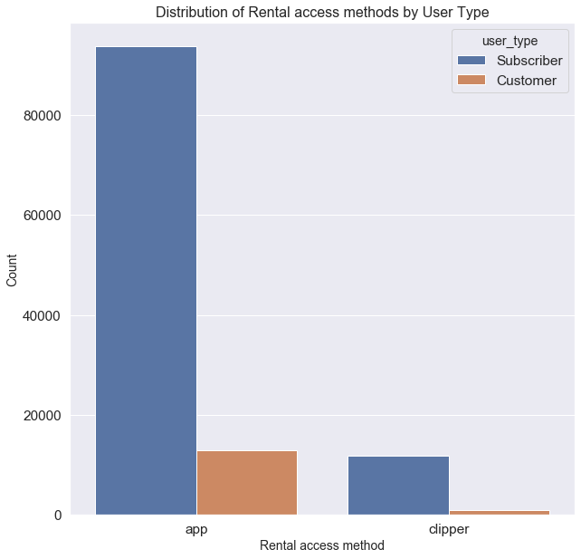

```python
# Variation of rental method by user type
plt.figure(figsize=[10,10])
sb.countplot(data = df_clean, x = 'rental_access_method', hue = 'user_type');
plt.xlabel('Rental access method',fontsize=14);
plt.ylabel('Count',fontsize=14);
plt.title('Distribution of Rental access methods by User Type',fontsize=16);
```

> **It looks like "app" is the most prevalent access method among both Subscribers and Customers.**

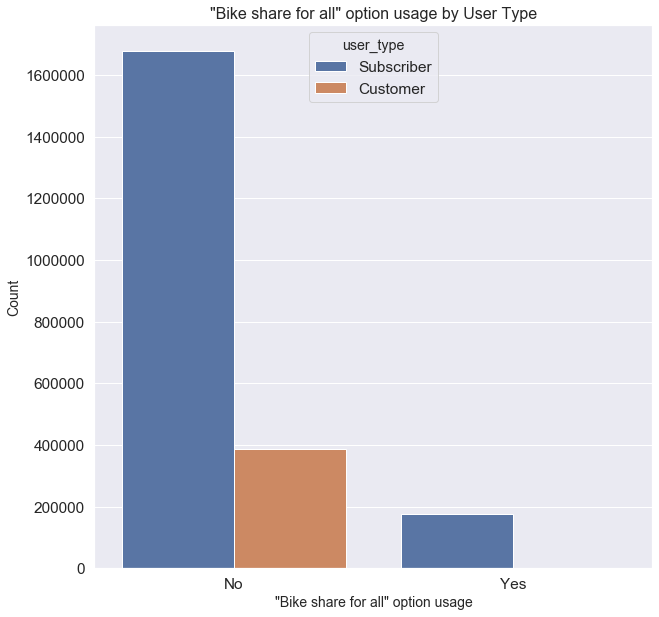

```python
# Usage of "bike share for all" option by user type
plt.figure(figsize=[10,10])
sb.countplot(data = df_clean, x = 'bike_share_for_all_trip', hue = 'user_type');
plt.xlabel('"Bike share for all" option usage',fontsize=14);
plt.ylabel('Count',fontsize=14);
plt.title('"Bike share for all" option usage by User Type',fontsize=16);
```

> **A small proportion of Subscribers seem to be using "Bike share for all" option whereas none of the Customers seem to be using this.**

```python
df_clean.describe()
```

|  | duration_sec | start_station_id | start_station_latitude | start_station_longitude | end_station_id | end_station_latitude | end_station_longitude | bike_id | duration_minutes |
| --- | --- | --- | --- | --- | --- | --- | --- | --- | --- |
| count | 2.482568e+06 | 2.402889e+06 | 2.482568e+06 | 2.482568e+06 | 2.400874e+06 | 2.482568e+06 | 2.482568e+06 | 2.482568e+06 | 2.482568e+06 |
| mean | 6.950274e+02 | 1.462239e+02 | 3.776501e+01 | -1.223498e+02 | 1.421282e+02 | 3.776475e+01 | -1.223477e+02 | 2.786856e+04 | 1.158379e+01 |
| std | 5.087060e+02 | 1.219512e+02 | 1.365971e-01 | 3.087030e-01 | 1.208701e+02 | 1.863361e-01 | 5.137763e-01 | 1.145282e+05 | 8.478433e+00 |
| min | 6.000000e+01 | 3.000000e+00 | 0.000000e+00 | -1.225143e+02 | 3.000000e+00 | 0.000000e+00 | -1.225143e+02 | 4.000000e+00 | 1.000000e+00 |
| 25% | 3.570000e+02 | 4.700000e+01 | 3.776931e+01 | -1.224130e+02 | 4.300000e+01 | 3.777003e+01 | -1.224116e+02 | 1.954000e+03 | 5.950000e+00 |
| 50% | 5.660000e+02 | 1.040000e+02 | 3.778053e+01 | -1.223983e+02 | 1.010000e+02 | 3.778065e+01 | -1.223974e+02 | 4.426000e+03 | 9.433333e+00 |
| 75% | 8.740000e+02 | 2.420000e+02 | 3.779539e+01 | -1.222914e+02 | 2.390000e+02 | 3.779539e+01 | -1.222934e+02 | 9.683000e+03 | 1.456667e+01 |
| max | 4.200000e+03 | 4.980000e+02 | 4.551000e+01 | 0.000000e+00 | 4.980000e+02 | 4.551000e+01 | 0.000000e+00 | 9.999410e+05 | 7.000000e+01 |

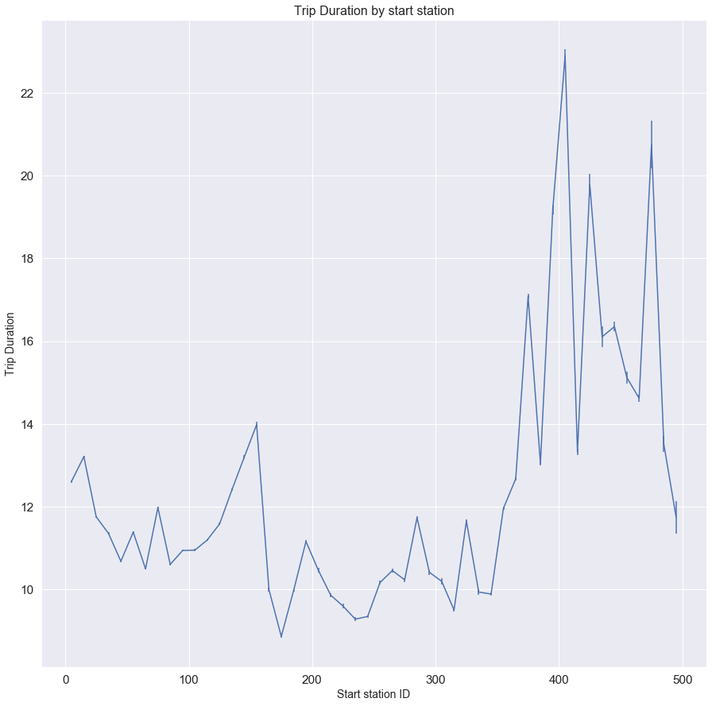

```python
#Trip duration by start station
# set bin edges, compute centers
bin_size = 10
xbin_edges = np.arange(0, df_clean['start_station_id'].max()+bin_size, bin_size)
xbin_centers = (xbin_edges + bin_size/2)[:-1]

# compute statistics in each bin
data_xbins = pd.cut(df_clean['start_station_id'], xbin_edges, right = False, include_lowest = True)
y_means = df_clean['duration_minutes'].groupby(data_xbins).mean()
y_sems = df_clean['duration_minutes'].groupby(data_xbins).sem()

# plot the summarized data
plt.figure(figsize=[15,15])
plt.errorbar(x = xbin_centers, y = y_means, yerr = y_sems);
plt.xlabel('Start station ID',fontsize=14);
plt.ylabel('Trip Duration',fontsize=14);
plt.title('Trip Duration by start station',fontsize=16);
```

> **This is interesting because the most frequent start stations distribution was concentrated towards the left i.e. lower values of station IDs (from the Univariate analysis). However, longer trip durations seem to be concentrated towards the right here i.e. longer trips are starting from stations with higher station IDs.**

### Talk about some of the relationships you observed in this part of the investigation. How did the feature(s) of interest vary with other features in the dataset?

> The trip duration on weekends seem to be higher as compared to weekdays (could be because people are using the bikes for sightseeing etc. on weekends). I have further investigated into this by plotting this separately for Subscribers and Users and our suspicion about that the bikes could've been used for more leisure purposes on weekends. seems to be true.

> It looks like "app" is the most prevalent access method among both Subscribers and Customers. A small proportion of Subscribers seem to be using "Bike share for all" option whereas none of the Customers seem to be using this.

> Most frequent start stations distribution was concentrated towards the left i.e. lower values of station IDs (from the Univariate analysis). However, longer trip durations seem to be concentrated towards the right here i.e. longer trips are starting from stations with higher station IDs as depicted in the line plot above.

### Did you observe any interesting relationships between the other features (not the main feature(s) of interest)?

> The average trip duration seems to be constant for subscribers who could be using these for routine tasks. However, the customers could be using them on weekends for sight-seeing or for leisure because there is a significant increase in trip duration over the weekends for "Customers".

## Multivariate Exploration

```python
df_clean.head(1)
```

|  | duration_sec | start_time | end_time | start_station_id | start_station_name | start_station_latitude | start_station_longitude | end_station_id | end_station_name | end_station_latitude | end_station_longitude | bike_id | user_type | bike_share_for_all_trip | rental_access_method | duration_minutes | trip_date | trip_time | trip_day | trip_month |
| --- | --- | --- | --- | --- | --- | --- | --- | --- | --- | --- | --- | --- | --- | --- | --- | --- | --- | --- | --- | --- |
| 6 | 1188 | 2019-01-31 23:54:38.901 | 2019-02-01 00:14:27.9000 | 34.0 | Father Alfred E Boeddeker Park | 37.783988 | -122.412408 | 146.0 | 30th St at San Jose Ave | 37.742314 | -122.42318 | 5114 | Subscriber | No | NaN | 19.8 | 01-31 | 23 | Thursday | January |

[figure not shown]

```python
plt.figure(figsize=[15,15])
sb.set(font_scale=1.4)
cat_means = df_clean.groupby(['user_type', 'trip_time']).mean()['duration_minutes']
cat_means = cat_means.reset_index(name = 'num_var2_avg')
cat_means = cat_means.pivot(index = 'trip_time', columns = 'user_type', values = 'num_var2_avg')
sb.heatmap(cat_means, annot = True, fmt = '.3f', cbar_kws = {'label' : 'mean(num_var2)'},cmap = 'BuPu');
plt.xlabel('User Type');
plt.ylabel('Trip Duration in minutes');
plt.title('Trip Duration by the hour by User Type');
```